# Class 7/Lab1: Clustering with Gaussian Mixture Models (GMMs)

Week 7 (10.17)

## Introduction

In this lab, we will use Gaussian Mixture Models (GMMs) to perform clustering on the `palmerpenguins` dataset. Our goal is to see if an unsupervised algorithm can discover the natural groupings (`species`) of penguins based on their physical measurements.

```r
# Clear environment and unload packages
rm(list = ls())
# The following line might show a note if no packages were loaded, which is normal.
pacman::p_unload(pacman::p_loaded())

# Load necessary packages
pacman::p_load(mclust, tidyverse, palmerpenguins, patchwork, cluster, here)
```

### Examine the Data

We load the `palmerpenguins` dataset. We will select only the numeric columns for our clustering analysis and remove any rows with missing data to ensure the algorithm runs smoothly.

```r
# Load the dataset
penguins <- read_csv(file.path(here(), "lectures", "07-clustering-kmeans", "data", "penguins.csv"))
# Inspect the data
head(penguins)
```

```
## # A tibble: 6 × 8
##   species island    bill_length_mm bill_depth_mm flipper_length_mm body_mass_g
##   <chr>   <chr>              <dbl>         <dbl>             <dbl>       <dbl>
## 1 Adelie  Torgersen           39.1          18.7               181        3750
## 2 Adelie  Torgersen           39.5          17.4               186        3800
## 3 Adelie  Torgersen           40.3          18                 195        3250
## 4 Adelie  Torgersen           NA            NA                  NA          NA
## 5 Adelie  Torgersen           36.7          19.3               193        3450
## 6 Adelie  Torgersen           39.3          20.6               190        3650
## # ℹ 2 more variables: sex <chr>, year <dbl>
```

```r
summary(penguins)
```

```
##       species          island    bill_length_mm  bill_depth_mm
##  Length   :344   Length   :344   Min.   :32.10   Min.   :13.10
##  N.unique :  3   N.unique :  3   1st Qu.:39.23   1st Qu.:15.60
##  N.blank  :  0   N.blank  :  0   Median :44.45   Median :17.30
##  Min.nchar:  6   Min.nchar:  5   Mean   :43.92   Mean   :17.15
##  Max.nchar:  9   Max.nchar:  9   3rd Qu.:48.50   3rd Qu.:18.70
##                                  Max.   :59.60   Max.   :21.50
##                                  NAs    :2       NAs    :2
##  flipper_length_mm  body_mass_g          sex           year
##  Min.   :172.0     Min.   :2700   Length   :344   Min.   :2007
##  1st Qu.:190.0     1st Qu.:3550   N.unique :  2   1st Qu.:2007
##  Median :197.0     Median :4050   N.blank  :  0   Median :2008
##  Mean   :200.9     Mean   :4202   Min.nchar:  4   Mean   :2008
##  3rd Qu.:213.0     3rd Qu.:4750   Max.nchar:  6   3rd Qu.:2009
##  Max.   :231.0     Max.   :6300   NAs      : 11   Max.   :2009
##  NAs    :2         NAs    :2
```

```r
# Preprocess the data: select relevant columns and remove NAs
penguins_clean <- penguins %>%
  select(bill_length_mm, bill_depth_mm, flipper_length_mm, body_mass_g) %>%
  na.omit()

cat("Dimensions of the cleaned data:", dim(penguins_clean))
```

```
## Dimensions of the cleaned data: 342 4
```

### Fitting the Gaussian Mixture Model

Now we’ll fit the GMM using the `mclust` function. A key advantage of the `mclust` package is that it automatically evaluates different models and numbers of clusters (from 1 to 9 by default), then selects the best one using the Bayesian Information Criterion (`BIC`).

```r
# Fit the GMM
gmm_model <- Mclust(penguins_clean)

# Print the summary of the best model
summary(gmm_model)
```

```
## ----------------------------------------------------
## Gaussian finite mixture model fitted by EM algorithm
## ----------------------------------------------------
##
## Mclust VEE (ellipsoidal, equal shape and orientation) model with 4 components:
##
##  log-likelihood   n df       BIC       ICL
##       -5159.255 342 32 -10505.22 -10545.59
##
## Clustering table:
##   1   2   3   4
## 155  64  59  64
```

**Plot Interpretation:** The summary tells us that the best model found has 4 components (clusters). This is one more than the number of penguin species in the dataset!It also tells us the type of covariance structure it found (e.g., “VEE” which means `ellipsoidal`, `variable volume`, `equal shape`).

### Visualizing and Interpreting the Results

#### BIC Plot

First, let’s look at the BIC values. The model with the highest BIC is considered the best. The plot clearly shows that the model with 4 clusters is the top-performing one.

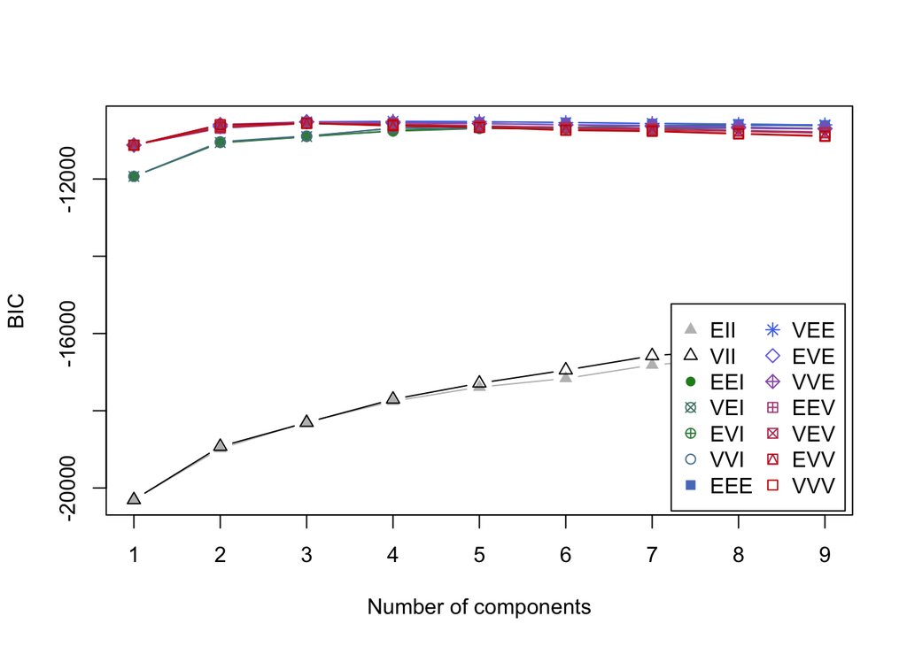

```r
# Plot the BIC values for different models and numbers of clusters
plot(gmm_model, what = "BIC")
```

#### Classification Plot

Next, we can visualize the cluster assignments. The plot shows the data points colored by their assigned cluster, with ellipses representing the shape and orientation of each cluster’s Gaussian distribution. We can see four groups.

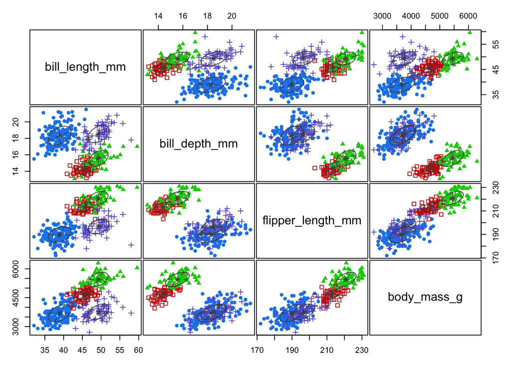

```r
# Plot the clustering results
plot(gmm_model, what = "classification")
```

#### Uncertainty Plot

We can also plot the model’s uncertainty. Points with higher uncertainty (larger circles) are ones the model is less sure about, often lying on the boundary between two clusters.

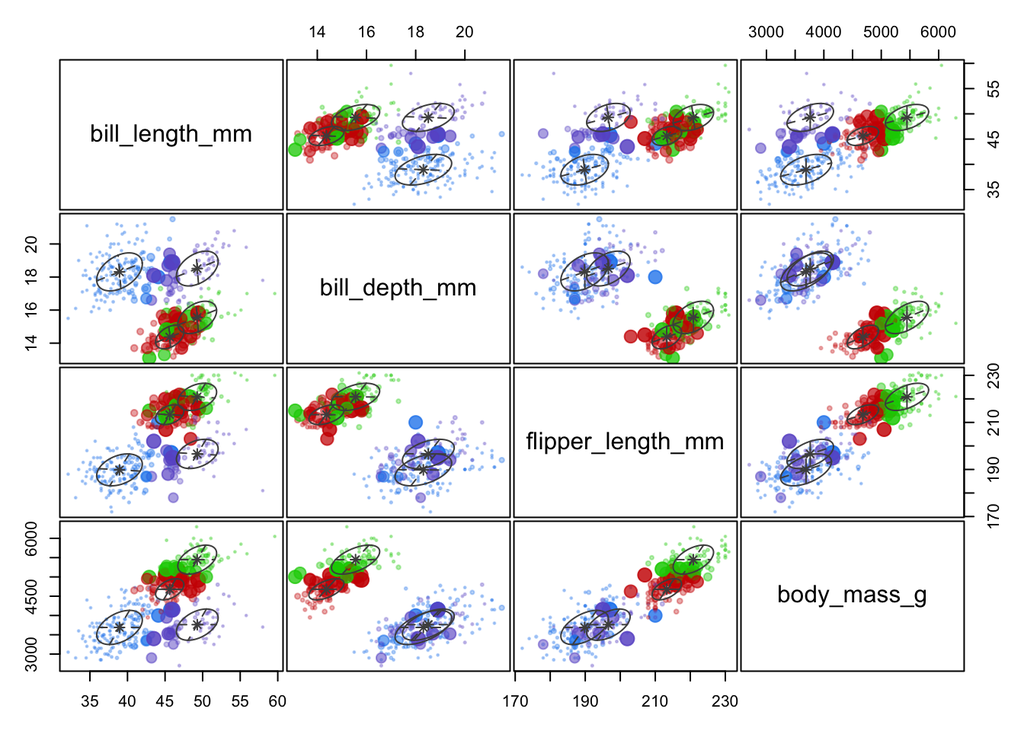

```r
# Plot the uncertainty of classification
plot(gmm_model, what = "uncertainty")
```

#### Analyzing Cluster Characteristics

To understand what these clusters represent, we can add the cluster assignments back to our data and then calculate the average measurements for each cluster. This helps us build a “profile” for each group.

```r
# Add cluster assignments to the data
penguins_clean$cluster <- as.factor(gmm_model$classification)

# Group by cluster and calculate the mean of each feature
cluster_summary <- penguins_clean %>%
  group_by(cluster) %>%
  summarize(
    Avg_Bill_Length = mean(bill_length_mm),
    Avg_Bill_Depth = mean(bill_depth_mm),
    Avg_Flipper_Length = mean(flipper_length_mm),
    Avg_Body_Mass = mean(body_mass_g),
    Count = n()
  )

# Print the summary table
knitr::kable(cluster_summary, caption = "Mean Feature Values by GMM Cluster")
```

Mean Feature Values by GMM Cluster

| cluster | Avg_Bill_Length | Avg_Bill_Depth | Avg_Flipper_Length | Avg_Body_Mass | Count |
| --- | --- | --- | --- | --- | --- |
| 1 | 38.87613 | 18.31097 | 189.8387 | 3692.258 | 155 |
| 2 | 45.64375 | 14.39219 | 213.2031 | 4674.219 | 64 |
| 3 | 49.52373 | 15.62203 | 221.5085 | 5511.864 | 59 |
| 4 | 49.25625 | 18.51094 | 196.4688 | 3755.469 | 64 |

Interpretation: From the table, we can derive insights about physical differences between the penguin species. For example, one cluster might have penguins with long flippers and high body mass, while another has penguins with deep bills.

#### Stretch Goal: Comparison with True Labels (not always possible)

```r
# We need to remove the NAs from the original 'species' column in the same way we did for the numeric data.
penguins_with_species <- penguins %>%
  filter(row_number() %in% as.numeric(rownames(penguins_clean)))
# Create a confusion matrix
table(gmm_cluster = gmm_model$classification, true_species = penguins_with_species$species)
```

```
##            true_species
## gmm_cluster Adelie Chinstrap Gentoo
##           1    151         4      0
##           2      1         0     63
##           3      0         0     59
##           4      0        62      2
```

### Alternative: Finding Optimal Clusters with the Silhouette Score

Instead of relying only on the `BIC`, we can use the `silhouette score` to evaluate cluster quality. We will loop through several possible numbers of clusters (`k`), fit a GMM for each, and calculate the average silhouette score. The `k` with the highest score is considered optimal.

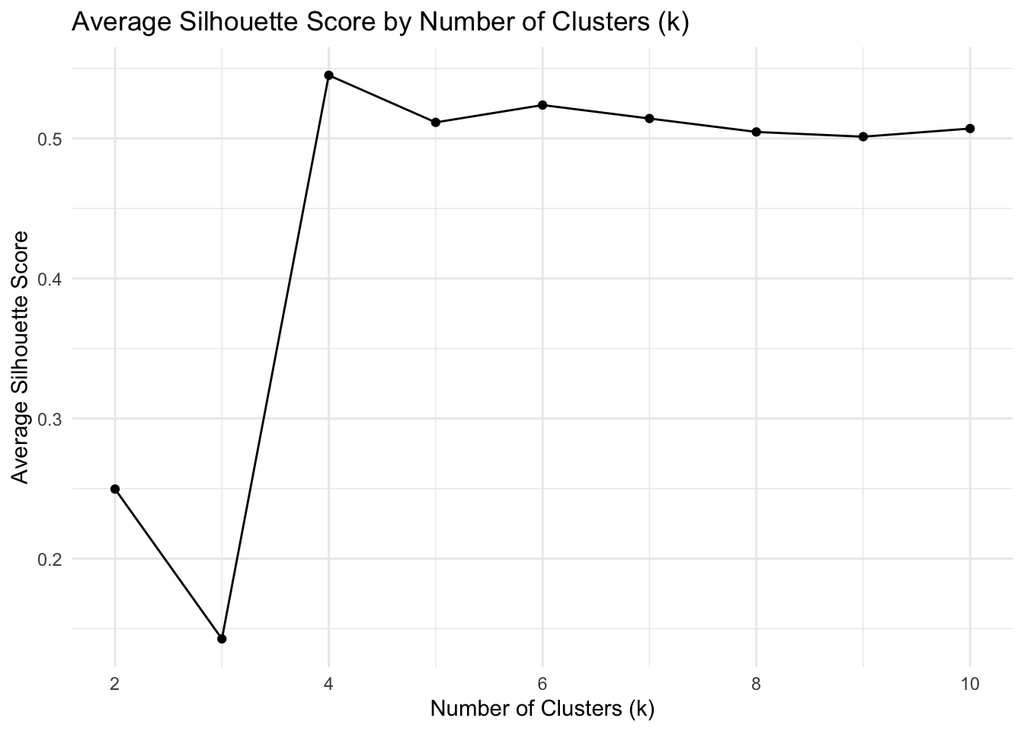

```r
# Calculate distance matrix once for efficiency
dist_matrix <- dist(penguins_clean)

# We will test k from 2 to 10
k_values <- 2:10
avg_sil_scores <- numeric(length(k_values))

for (i in 1:length(k_values)) {
  k <- k_values[i]

  # Fit GMM for a specific k
  gmm_fit <- Mclust(penguins_clean, G = k, verbose = FALSE)

  # If the model fails for a given k, it might return NULL classifications
  if(!is.null(gmm_fit)) {
    # Calculate silhouette score
    sil <- silhouette(gmm_fit$classification, dist_matrix)

    # Store the average silhouette width
    avg_sil_scores[i] <- mean(sil[, "sil_width"])
  } else {
    avg_sil_scores[i] <- NA # Assign NA if model failed
  }
}

# Create a data frame of the results
sil_results <- data.frame(k = k_values, avg_sil = avg_sil_scores)

# Plot the results
ggplot(sil_results, aes(x = k, y = avg_sil)) +
  geom_line() +
  geom_point() +
  labs(title = "Average Silhouette Score by Number of Clusters (k)",
       x = "Number of Clusters (k)",
       y = "Average Silhouette Score") +
  theme_minimal()
```

```r
# Find the optimal k
optimal_k <- sil_results$k[which.max(sil_results$avg_sil)]
cat("\nOptimal number of clusters based on silhouette score is:", optimal_k, "\n")
```

```
##
## Optimal number of clusters based on silhouette score is: 4
```

Average silhouette score peaks at `k = 4` (agreeing with BIC), suggesting it’s the best choice for our data.